# Fredon Township School District — NJ School Data Almanac – NJ District Profiles

NJ School Data Almanac

Fredon Township School District

SUSSEX COUNTY · TRADITIONAL PUBLIC DISTRICT · DFG GH · 220 STUDENTS (2026)

220

Students

65.4%

Gr 3-8 ELA

6.9%

Chronically absent

$21,492

Per pupil

*7 things the data says about Fredon Township School District. Every figure is computed from New Jersey Department of Education data via the njschooldata package — nothing is estimated. Comparisons use District Factor Group (DFG) peers (76 districts in DFG GH).*

No. 1 ACHIEVEMENT

## Fredon’s Math Proficiency Fell to 35% in 2022 and Has Recovered Only Halfway by 2024

On the NJSLA, math scores cratered during the pandemic and remain below their pre-COVID level even as reading rebounded past it.

Reading and math told two different stories at Fredon Township School District after the pandemic. On the NJSLA tests for grades 3-8, ELA proficiency dipped only modestly, from 63.1% in 2019 to 56.7% in 2022, and by 2024 had climbed to 65.4% — higher than where it started. Math followed a much steeper path down and a much slower path back up.

Math proficiency stood at 56.3% in 2019. By the spring of 2022 it had collapsed to 35.0%, a drop of more than 21 percentage points. Recovery has been partial: 38.8% in 2023 and 47.5% in 2024. That 2024 figure leaves Fredon’s math proficiency still nearly nine points below its pre-pandemic mark, even as reading has fully recovered and then some.

The gap between the two subjects is now stark — 65.4% of students reached proficiency in ELA in 2024 versus 47.5% in math, a difference of nearly 18 percentage points. For a district this small, where a single grade level can swing the average, the divergence raises a question the data alone cannot answer: what about math instruction or math recovery has lagged so far behind reading?

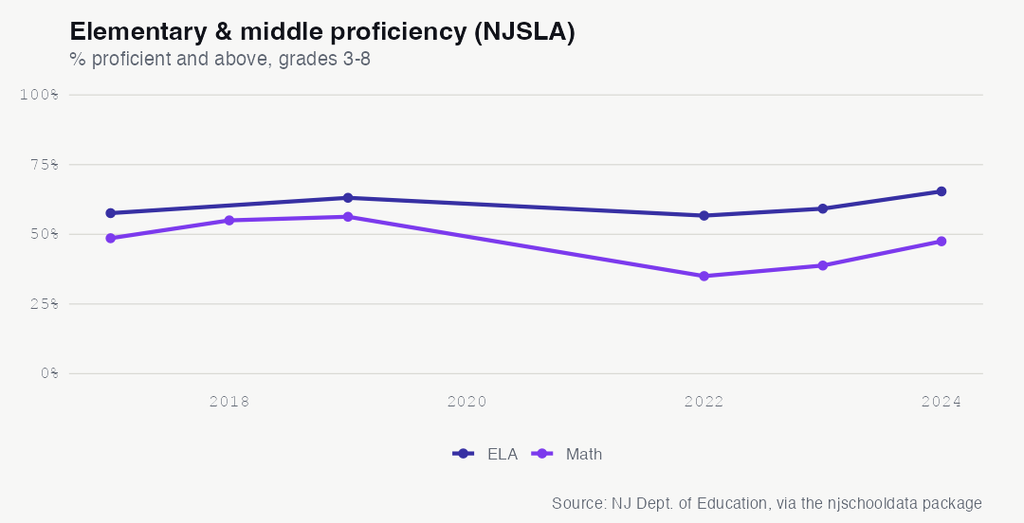

See the underlying data ›

No. 2 ENROLLMENT

Fredon Township School District spent most of the last decade shrinking. Enrollment slid from 250 students in 2015 to a low of 175 in 2021 — a six-year stretch that included a sharp 13.7% drop in 2019 alone. For a small rural K-8 district, that kind of sustained decline raises hard questions about staffing, class sizes, and fixed costs spread across fewer children.

At 220 students, Fredon remains 30 below its 2015 level, a net decline of 12.0% across the period. But the direction has clearly flipped. The question for the board is whether this rebound reflects a durable shift in the township’s young families or a temporary bump that the next few enrollment counts will test.

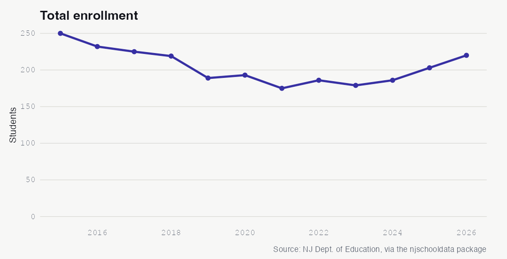

See the underlying data ›

No. 3 DEMOGRAPHICS

## Hispanic Enrollment Nearly Quadrupled at Fredon, Rising From 4% to 15% Since 2015

An almost entirely white district a decade ago, Fredon has seen its Hispanic share climb 11 points while its white share fell.

In 2015, Fredon Township School District was 92.4% white, with Hispanic students making up just 4.0% of enrollment. A decade later the picture looks different. By 2026, the Hispanic share had reached 15.0% — nearly four times its starting point and an increase of 11.0 percentage points, the largest demographic change in the district.

The shift was gradual and steady rather than sudden. The Hispanic share crossed 8% by 2017, topped 11% by 2019, and has hovered between 12% and 16% since. Over the same span the white share fell 10.6 points, from 92.4% to 81.8%, while the Asian share edged down 2.2 points.

For a small rural district in Sussex County, this is a meaningful change in who sits in the classrooms. It arrives alongside a recent rise in economic need and a growing math-achievement challenge — a combination that prompts the question of how Fredon is adapting instruction and support for a student body that no longer looks the way it did ten years ago.

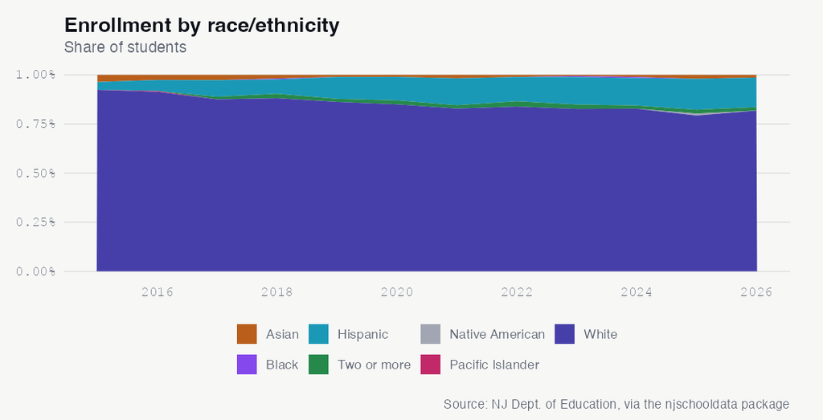

See the underlying data ›

No. 4 ATTENDANCE

## Chronic Absenteeism at Fredon Spiked to 21% in 2022, Then Fell Below the Peer Median

After a pandemic-era surge, the district’s chronic absence rate dropped to 6.9% in 2024 — well under the 9.6% median for similar districts.

Before the pandemic, almost every Fredon student showed up regularly. Chronic absenteeism — the share of students missing at least 10% of school days — sat at just 2.2% in 2019. Then COVID upended attendance. By 2022 the rate had soared to 21.4%, meaning roughly one in five students was chronically absent.

The recovery has been faster here than the spike. The rate fell to 8.5% in 2023 and to 6.9% in 2024. That 2024 figure is notably better than the 9.6% median among Fredon’s District Factor Group GH peers, putting the district ahead of comparable communities on getting kids back into seats.

Still, 6.9% is more than three times the 2.2% Fredon recorded in 2019. The district has clawed back most of the pandemic damage and now outperforms its peers, but whether it can return to its pre-COVID baseline of near-universal attendance is the open question its trend line poses.

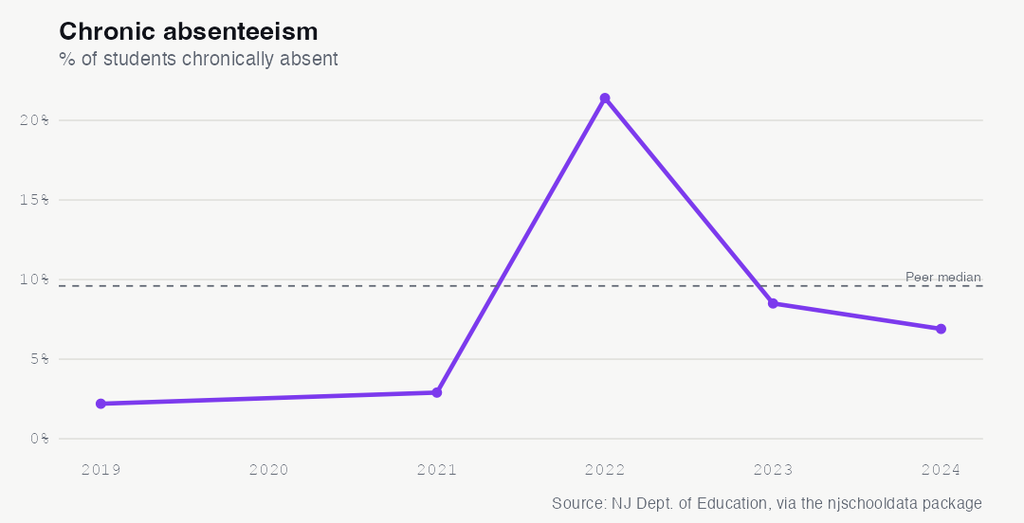

See the underlying data ›

No. 5 FINANCE

## Fredon Spends $21,492 per Student — Up 41% Since 2014 as Enrollment Fell

Per-pupil spending now ranks in the 74th percentile among DFG GH peers, even as the number of students it serves dropped sharply.

Fredon Township School District spent $21,492 per pupil in 2024, up 41.4% from $15,199 in 2014. That places the district in the 74th percentile among its District Factor Group GH peers, above the peer median of $20,442. For a small district, rising per-pupil costs are partly a story of arithmetic: when enrollment falls, fixed costs get spread across fewer students.

And Fredon’s enrollment did fall over much of this period. The district’s average daily enrollment for spending purposes dropped from 276 in 2014 to a low of 176 in 2021, recovering only to 187 by 2024. Fewer children sharing the same building, staff, and overhead pushes per-pupil figures up even when total spending is flat.

The composition of that spending in 2025 shows 46.8% going to the classroom, 23.6% to support services, 17.4% to plant operations, and 10.7% to administration. With enrollment now climbing back toward 220, the question for taxpayers is whether the recent rebound in students will ease the per-pupil pressure — or whether costs will keep rising regardless.

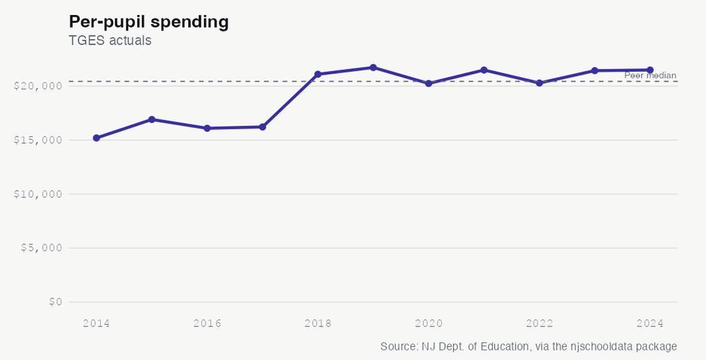

See the underlying data ›

No. 6 DEMOGRAPHICS

## Economic Need at Fredon Whipsawed From 3.3% to 13.2% in Two Years

After years of decline, the share of students qualifying for free or reduced-price lunch quadrupled between 2024 and 2026.

For most of the past decade, economic need appeared to be easing at Fredon Township School District. The share of students qualifying for free or reduced-price lunch — a standard proxy for family poverty — fell from 9.6% in 2015 to just 3.3% in 2024, when only six students qualified.

Then it reversed sharply. The rate jumped to 12.8% in 2025 and 13.2% in 2026, when 29 students qualified — nearly five times the 2024 count. In a district of about 220 students, that swing of roughly 23 children in two years is large enough to reshape the classroom mix.

The timing tracks with Fredon’s enrollment rebound and its rising Hispanic share, suggesting the families moving into the district may differ economically from those already there. Whether this jump in measured need reflects a lasting demographic shift or a one-time change in how families qualify is a question the next few years of data will settle.

See the underlying data ›

No. 7 EQUITY

## Fredon Girls Outscored Boys on the NJSLA Reading Test by 17 Points in 2024

Among grades 3-8, 76.8% of female students reached proficiency in ELA versus 59.5% of male students.

Fredon’s 2024 NJSLA reading results reveal a sizable gender gap. Among students in grades 3-8, 76.8% of female students reached proficiency in ELA, compared with 59.5% of male students — a difference of more than 17 percentage points. The district’s overall ELA proficiency was 65.4%, sitting between the two.

A reading gap favoring girls is common across schools, but the size of this one stands out, with more than three in four girls proficient against fewer than three in five boys. White students, the district’s largest group, posted 60.9% proficiency, close to the male figure.

In a district this small, a single cohort can move these averages, so one year’s gap is not a trend. But the pattern is worth watching: if boys at Fredon continue to trail in reading, the question becomes what the district can do to close a gap that is wide even by typical standards.

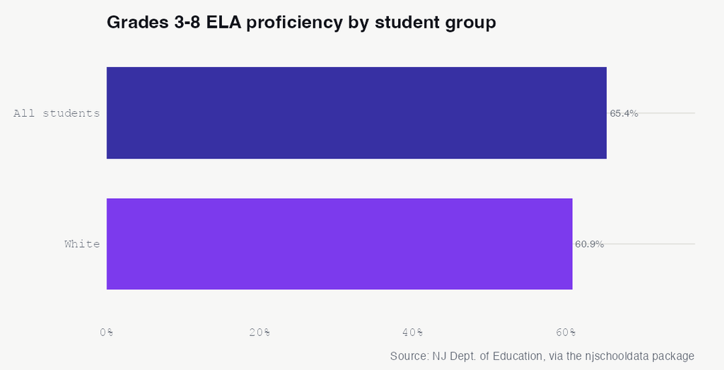

See the underlying data ›

## The Almanac

The full longitudinal record behind the stories above. Every number a reader can check.

### Enrollment (total)

| year | students | yoy | yoy_pct |
| --- | --- | --- | --- |
| 2015 | 250 | NA | NA |
| 2016 | 232 | -18 | -7.2 |
| 2017 | 225 | -7 | -3 |
| 2018 | 219 | -6 | -2.7 |
| 2019 | 189 | -30 | -13.7 |
| 2020 | 193 | 4 | 2.1 |
| 2021 | 175 | -18 | -9.3 |
| 2022 | 186 | 11 | 6.3 |
| 2023 | 179 | -7 | -3.8 |
| 2024 | 186 | 7 | 3.9 |
| 2025 | 203 | 17 | 9.1 |
| 2026 | 220 | 17 | 8.4 |

### Demographic share (%) by year

| end_year | white | black | hispanic | asian | native_american | pacific_islander | multiracial |
| --- | --- | --- | --- | --- | --- | --- | --- |
| 2015 | 92.4 | 0 | 4 | 3.6 | 0 | 0 | 0 |
| 2016 | 91.4 | 0 | 5.6 | 2.6 | 0 | 0.4 | 0 |
| 2017 | 87.6 | 0 | 8.4 | 2.7 | 0 | 0 | 1.3 |
| 2018 | 88.1 | 0.5 | 7.3 | 1.8 | 0 | 0 | 2.3 |
| 2019 | 86.2 | 0 | 11.1 | 1.1 | 0 | 0 | 1.6 |
| 2020 | 85 | 0 | 11.9 | 1 | 0 | 0 | 2.1 |
| 2021 | 82.9 | 0 | 13.7 | 1.7 | 0 | 0 | 1.7 |
| 2022 | 83.9 | 0 | 12.4 | 1.1 | 0 | 0 | 2.7 |
| 2023 | 82.7 | 0.6 | 14 | 0.6 | 0 | 0 | 2.2 |
| 2024 | 82.8 | 0.5 | 14 | 1.1 | 0 | 0 | 1.6 |
| 2025 | 79.3 | 0 | 15.8 | 2 | 1 | 0 | 2 |
| 2026 | 81.8 | 0 | 15 | 1.4 | 0 | 0 | 1.8 |

### Special populations (LEP, FRL)

| end_year | subgroup | students | pct |
| --- | --- | --- | --- |
| 2015 | lep | 0 | 0.0 |
| 2015 | free_reduced_lunch | 24 | 9.6 |
| 2016 | lep | 0 | 0.0 |
| 2016 | free_reduced_lunch | 21 | 9.1 |
| 2017 | lep | 0 | 0.0 |
| 2017 | free_reduced_lunch | 22 | 9.8 |
| 2018 | lep | 0 | 0.0 |
| 2018 | free_reduced_lunch | 23 | 10.5 |
| 2019 | lep | 0 | 0.0 |
| 2019 | free_reduced_lunch | 18 | 9.5 |
| 2020 | lep | 0 | 0.0 |
| 2020 | free_reduced_lunch | 14 | 7.2 |
| 2021 | lep | 0 | 0.0 |
| 2021 | free_reduced_lunch | 11 | 6.3 |
| 2022 | lep | 0 | 0.0 |
| 2022 | free_reduced_lunch | 10 | 5.4 |
| 2023 | lep | 0 | 0.0 |
| 2023 | free_reduced_lunch | 6 | 3.4 |
| 2024 | lep | 0 | 0.0 |
| 2024 | free_reduced_lunch | 6 | 3.3 |
| 2025 | lep | 0 | 0.0 |
| 2025 | free_reduced_lunch | 26 | 12.8 |
| 2026 | lep | 0 | 0.0 |
| 2026 | free_reduced_lunch | 29 | 13.2 |

### NJSLA grades 3-8 proficiency (% proficient+, enrollment-weighted across grades)

| testing_year | test_name | prof |
| --- | --- | --- |
| 2017 | ela | 57.6 |
| 2017 | math | 48.6 |
| 2018 | math | 55.0 |
| 2019 | ela | 63.1 |
| 2019 | math | 56.3 |
| 2022 | ela | 56.7 |
| 2022 | math | 35.0 |
| 2023 | ela | 59.2 |
| 2023 | math | 38.8 |
| 2024 | ela | 65.4 |
| 2024 | math | 47.5 |

### NJSLA ELA proficiency by subgroup (2024, grades 3-8)

| subgroup | prof |
| --- | --- |
| female | 76.8 |
| total_population | 65.4 |
| white | 60.9 |
| male | 59.5 |
| non_ed | NA |

### Chronic absenteeism (% chronically absent)

| year | chronic_pct |
| --- | --- |
| 2019 | 2.2 |
| 2021 | 2.9 |
| 2022 | 21.4 |
| 2023 | 8.5 |
| 2024 | 6.9 |

### Disciplinary removals

[output not shown]

### Police notifications (incident counts)

| year | violence | weapons | vandalism | substances | hib | other |
| --- | --- | --- | --- | --- | --- | --- |
| 2019 | 0 | 0 | 0 | 0 | 0 | 0 |
| 2020 | 0 | 0 | 0 | 0 | 0 | 0 |
| 2021 | NA | NA | NA | NA | NA | NA |
| 2022 | NA | NA | NA | NA | NA | NA |
| 2023 | 0 | 1 | 0 | 0 | 0 | 0 |
| 2024 | 0 | 0 | 0 | 0 | 0 | 0 |

### HIB (harassment/intimidation/bullying) investigations

| end_year | alleged | confirmed |
| --- | --- | --- |
| 2019 | 7 | 1 |
| 2020 | 0 | 1 |
| 2021 | 0 | 0 |
| 2022 | 0 | 0 |
| 2023 | 5 | 3 |
| 2024 | 1 | 0 |

### Special education (raw rows; inspect for classification rate)

| end_year | district_id |
| --- | --- |
| 2024 | 1630 |

### Per-pupil spending (TGES actuals)

| year | per_pupil | rank | ade |
| --- | --- | --- | --- |
| 2014 | 15199 | 36 | 276 |
| 2015 | 16908 | 43 | 246 |
| 2016 | 16095 | 36 | 233 |
| 2017 | 16218 | 33 | 240 |
| 2018 | 21101 | 53 | 218 |
| 2019 | 21726 | 51 | 194 |
| 2020 | 20246 | 45 | 191 |
| 2021 | 21490 | 46 | 176 |
| 2022 | 20287 | 41 | 184 |
| 2023 | 21434 | 43 | 177 |
| 2024 | 21492 | 41 | 187 |

### Spending composition shares (2025)

| classroom_share | support_services_share | administration_share | plant_ops_share | food_service_share | extracurricular_share | equipment_share |
| --- | --- | --- | --- | --- | --- | --- |
| 46.8 | 23.6 | 10.7 | 17.4 | NA | 1.2 | 2.2 |

### Staffing ratios

| end_year | student_teacher_district | student_admin_district | student_counselor_district | student_nurse_district |
| --- | --- | --- | --- | --- |
| 2024 | 11:1 | 52:1 | 209:1 | 209:1 |

Back to top